# CWRU IMMI Analysis

Amit K Verma, Roger H French, Jennifer L W Carter

December 6, 2017

License: [CC-A-NC-SA-4.0](http://creativecommons.org/licenses/by-nc-sa/4.0/)

## Title: Physics Informed Network Models: A Data Science Approach to Metals Design

**Question**: To build a model which can correlate the performance from a known compositional map.

- Intial Frame Work
  - Known compositional map
  - Known measure of performance - Strength/YS/Hardness

## Datasets

- Two different datasets, each containing data from different instrument
  - First, Hardness measurements, specific to an area equal to the size of indent
  - Second, XEDS compositional data, specific to an area equal to the size of interaction volume

**Training Dataset: Hardness Data**

```r
setwd("../Data")
df <- read.csv("Training_Hardness.csv", header = TRUE, stringsAsFactors=FALSE)
df$Location.Z <- df$disp.ref.z + df$dz*df$Location.Z
df$Location.X <- df$disp.ref.x + df$dx*df$Location.X
drops <- c("disp.ref.z","disp.ref.x", "dz", "dx")
strength <- df[,!(names(df) %in% drops)]
```

**Testing Dataset: Hardness Data**

```r
setwd("../Data")
df <- read.csv("Testing_Hardness.csv", header = TRUE, stringsAsFactors=FALSE)
df$Location.Z <- df$disp.ref.z + df$dz*df$Location.Z
df$Location.X <- df$disp.ref.x + df$dx*df$Location.X
drops <- c("disp.ref.z","disp.ref.x", "dz", "dx")
strength2 <- df[,!(names(df) %in% drops)]
```

**Training Dataset: Composition Data**

```r
setwd("../Data")
df <- read.csv("Training_XEDS.csv", header = TRUE, stringsAsFactors=FALSE)
df$Location.Z <- df$disp.ref.z + df$dz*df$Location.Z
df$Location.X <- df$disp.ref.x + df$dx*df$Location.X
drops <- c("disp.ref.z","disp.ref.x", "dz", "dx")
composition <- df[,!(names(df) %in% drops)]
l <- length(composition$Al)
sum <- 0

# 'for' loop to normalize the results to 100%

for (i in 1:l)
  {sum <- composition$Al[i] + composition$Cu[i] + composition$Mg[i] + composition$Zn[i]
   composition$Al[i] <- (composition$Al[i]/sum)*100
   composition$Cu[i] <- (composition$Cu[i]/sum)*100
   composition$Mg[i] <- (composition$Mg[i]/sum)*100
   composition$Zn[i] <- (composition$Zn[i]/sum)*100}
```

**Testing Dataset: Composition Data**

```r
setwd("../Data")
df <- read.csv("Testing_XEDS.csv", header = TRUE, stringsAsFactors=FALSE)
df$Location.Z <- df$disp.ref.z + df$dz*df$Location.Z
df$Location.X <- df$disp.ref.x + df$dx*df$Location.X
drops <- c("disp.ref.z","disp.ref.x", "dz", "dx")
composition2 <- df[,!(names(df) %in% drops)]
l <- length(composition2$Al)
sum <- 0

# 'for' loop to normalize the results to 100%

for (i in 1:l)
  {sum <- composition2$Al[i] + composition2$Cu[i] + composition2$Mg[i] + composition2$Zn[i]
   composition2$Al[i] <- (composition2$Al[i]/sum)*100
   composition2$Cu[i] <- (composition2$Cu[i]/sum)*100
   composition2$Mg[i] <- (composition2$Mg[i]/sum)*100
   composition2$Zn[i] <- (composition2$Zn[i]/sum)*100}
```

## Target Data Structure

- Requirement of target data structure is to enable navigation through all data
- To enable this, we put the data from all different data-sets in a single reference system
- Once the data is in single reference system, we can merge, visualize and correlate

### Training Data

- r = correlation coefficients
- p = p values for the correlation test

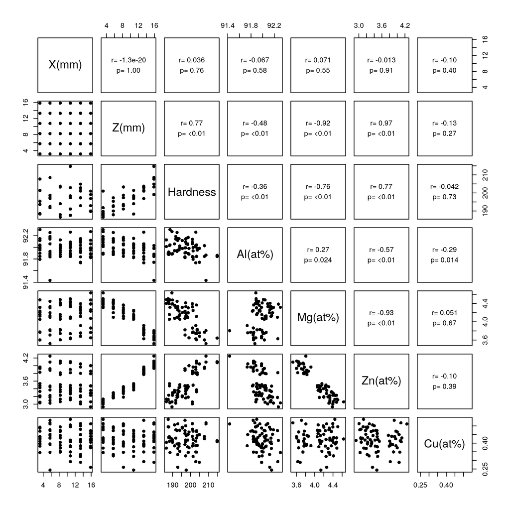

```r
# Combining data-sets for target data structure
df <- merge(strength, composition, by = c("Location.X","Location.Z"))

# Subsetting
data <- subset(df, select = c(Location.X, Location.Z, Hardness, Al, Zn, Mg, Cu))

# Changing to atomic percentage
N <- 6.022e23
l <- length(data$Al)
columns <- c("Alat","Mgat","Znat", "Cuat")
data[,columns] <- NA

for (i in 1:l)
  {data$Alat[i] <- data$Al[i]*N/27
  data$Znat[i] <- data$Zn[i]*N/65.4
  data$Mgat[i] <- data$Mg[i]*N/24.3
  data$Cuat[i] <- data$Cu[i]*N/63.5}

for (i in 1:l)
  {sum <- data$Alat[i] + data$Cuat[i] + data$Mgat[i] + data$Znat[i]
   data$Alat[i] <- (data$Alat[i]/sum)*100
   data$Cuat[i] <- (data$Cuat[i]/sum)*100
   data$Mgat[i] <- (data$Mgat[i]/sum)*100
   data$Znat[i] <- (data$Znat[i]/sum)*100}

# Changing column names
colnames(data) <- c("X.mm", "Z.mm", "Hardness", "Al.wt", "Zn.wt", "Mg.wt", "Cu.wt",
                    "Al.at", "Mg.at", "Zn.at", "Cu.at")


# pair plot of training dataset
a <- c(1,2,3,8,9,10,11)
temp <- data[,a]
colnames(temp) <- c("X(mm)", "Z(mm)", "Hardness", "Al(at%)", "Mg(at%)",
                    "Zn(at%)", "Cu(at%)")
pairs(temp, upper.panel = panel.cor, pch = 16)
```

**Discussion**

- From the data, we can see that Mg & Zn are highly correlated with Hardness Value
- To define H(x,z) = f(composition), we can use Mg & Zn; and can leave out Al & Cu

### Defining Regions

- Region 1
  - $Mg_{32}Zn_{31.9}Al_{17.1}$ as in precipitate

```r
Mg <- data$Mg.at
Zn <- data$Zn.at
df = data.frame(Mg,Zn)

for(i in 1:length(df$Mg)){
  if(df$Mg[i] > df$Zn[i]){
    df$MgZn[i] <- df$Zn[i]
    df$Mgexcess[i] <- df$Mg[i] - df$Zn[i]
    df$Znexcess[i] <- 0
  }
  if(df$Mg[i] < df$Zn[i]){
    df$MgZn[i] <- df$Mg[i]
    df$Mgexcess[i] <- 0
    df$Znexcess[i] <- df$Zn[i] - df$Mg[i]
  }
}

df$Hardness <-  data$Hardness
```

- Region 2
  - $Mg_Zn_{2} as in precipitate

```r
df2 = data.frame(Mg,Zn)

for(i in 1:length(df2$Mg)){
  if(df2$Mg[i] > df2$Zn[i]/2){
    df2$MgZn2[i] <- df2$Zn[i]/2
    df2$Mgexcess[i] <- df2$Mg[i] - df2$Zn[i]/2
    df2$Znexcess[i] <- 0
  }
  if(df2$Mg[i] < df2$Zn[i]/2){
    df2$MgZn2[i] <- df2$Mg[i]
    df2$Mgexcess[i] <- 0
    df2$Znexcess[i] <- df2$Zn[i] - 2*df2$Mg[i]
  }
}

df2$Hardness <-  data$Hardness
df2$Z <-  data$Z.mm
```

### netSEM quantification

- Region 1: $Mg_{32}Zn_{31.9}Al_{17.1}$ as precipitate

```r
library(sgSEM)
ans <- sgSEM(df, str = TRUE, endogenous = 6)
```

```
## Regress Dep ~ Indep  Hardness ~ Mg
## Regress Dep ~ Indep  Hardness ~ MgZn
## Regress Dep ~ Indep  Hardness ~ Mgexcess
## Regress Dep ~ Indep  Hardness ~ Znexcess
## Regress Dep ~ Indep  Hardness ~ Zn
## Regress Dep ~ Indep  MgZn ~ Mg
## Regress Dep ~ Indep  MgZn ~ Mgexcess
## Regress Dep ~ Indep  MgZn ~ Znexcess
## Regress Dep ~ Indep  MgZn ~ Zn
## Regress Dep ~ Indep  Mgexcess ~ Mg
## Regress Dep ~ Indep  Mgexcess ~ MgZn
## Regress Dep ~ Indep  Mgexcess ~ Znexcess
## Regress Dep ~ Indep  Mgexcess ~ Zn
## Regress Dep ~ Indep  Znexcess ~ Mg
## Regress Dep ~ Indep  Znexcess ~ MgZn
## Regress Dep ~ Indep  Znexcess ~ Mgexcess
## Regress Dep ~ Indep  Znexcess ~ Zn
## Regress Dep ~ Indep  Zn ~ Mg
## Regress Dep ~ Indep  Zn ~ MgZn
## Regress Dep ~ Indep  Zn ~ Mgexcess
## Regress Dep ~ Indep  Zn ~ Znexcess
```

```r
plot(ans)
```

```
## The cutoff value is lower than all of the adjusted R-sqr values: Only solid lines
```

[interactive chart not shown]

```r
summary(ans)
```

```
## sgSEM: It consideres all exagenous variables and finds the best regression model
##
## Exagenous (Multiple exagenous): Mg MgZn Mgexcess Znexcess Zn
## Endegenous: Hardness
##
## Chosen models:
```

```
##  [1] "Mg ---> Hardness | ISQRoot (Adjusted R-square =  0.5706 )"
##  [2] "MgZn ---> Hardness | SQuad (Adjusted R-square =  0.45504 )"
##  [3] "Mgexcess ---> Hardness | SL (Adjusted R-square =  0.55769 )"
##  [4] "Znexcess ---> Hardness | nls (Adjusted R-square =  0.44522 )"
##  [5] "Zn ---> Hardness | Exp (Adjusted R-square =  0.59142 )"
##  [6] "Mg ---> MgZn | Quad (Adjusted R-square =  0.73657 )"
##  [7] "Mgexcess ---> MgZn | Quad (Adjusted R-square =  0.91673 )"
##  [8] "Znexcess ---> MgZn | Quad (Adjusted R-square =  0.37983 )"
##  [9] "Zn ---> MgZn | Quad (Adjusted R-square =  0.94093 )"
## [10] "Mg ---> Mgexcess | Quad (Adjusted R-square =  0.93713 )"
## [11] "MgZn ---> Mgexcess | SL (Adjusted R-square =  0.91298 )"
## [12] "Znexcess ---> Mgexcess | Quad (Adjusted R-square =  0.54249 )"
## [13] "Zn ---> Mgexcess | Quad (Adjusted R-square =  0.94989 )"
## [14] "Mg ---> Znexcess | Quad (Adjusted R-square =  0.76734 )"
## [15] "MgZn ---> Znexcess | SL (Adjusted R-square =  0.24757 )"
## [16] "Mgexcess ---> Znexcess | Quad (Adjusted R-square =  0.5282 )"
## [17] "Zn ---> Znexcess | Quad (Adjusted R-square =  0.82755 )"
## [18] "Mg ---> Zn | ISQRoot (Adjusted R-square =  0.86237 )"
## [19] "MgZn ---> Zn | SL (Adjusted R-square =  0.86697 )"
## [20] "Mgexcess ---> Zn | nls (Adjusted R-square =  0.94059 )"
## [21] "Znexcess ---> Zn | Quad (Adjusted R-square =  0.67987 )"
```

- Region 2: $Mg_Zn_{2} as precipitate

```r
temp <- df2[,c(7,1:4,6)]
ans <- sgSEM(temp,str = TRUE, endogenous = 6)
```

```
## Regress Dep ~ Indep  Hardness ~ Z
## Regress Dep ~ Indep  Hardness ~ Zn
## Regress Dep ~ Indep  Hardness ~ MgZn2
## Regress Dep ~ Indep  Hardness ~ Mgexcess
## Regress Dep ~ Indep  Hardness ~ Mg
## Regress Dep ~ Indep  Zn ~ Z
## Regress Dep ~ Indep  Zn ~ MgZn2
## Regress Dep ~ Indep  Zn ~ Mgexcess
## Regress Dep ~ Indep  Zn ~ Mg
## Regress Dep ~ Indep  MgZn2 ~ Z
## Regress Dep ~ Indep  MgZn2 ~ Zn
## Regress Dep ~ Indep  MgZn2 ~ Mgexcess
## Regress Dep ~ Indep  MgZn2 ~ Mg
## Regress Dep ~ Indep  Mgexcess ~ Z
## Regress Dep ~ Indep  Mgexcess ~ Zn
## Regress Dep ~ Indep  Mgexcess ~ MgZn2
## Regress Dep ~ Indep  Mgexcess ~ Mg
## Regress Dep ~ Indep  Mg ~ Z
## Regress Dep ~ Indep  Mg ~ Zn
## Regress Dep ~ Indep  Mg ~ MgZn2
## Regress Dep ~ Indep  Mg ~ Mgexcess
```

```r
plot(ans)
```

```
## The cutoff value is lower than all of the adjusted R-sqr values: Only solid lines
```

[interactive chart not shown]

```r
summary(ans)
```

```
## sgSEM: It consideres all exagenous variables and finds the best regression model
##
## Exagenous (Multiple exagenous): Z Zn MgZn2 Mgexcess Mg
## Endegenous: Hardness
##
## Chosen models:
```

```
##  [1] "Z ---> Hardness | SQuad (Adjusted R-square =  0.6102 )"
##  [2] "Zn ---> Hardness | Exp (Adjusted R-square =  0.59142 )"
##  [3] "MgZn2 ---> Hardness | Exp (Adjusted R-square =  0.59093 )"
##  [4] "Mgexcess ---> Hardness | Log (Adjusted R-square =  0.59802 )"
##  [5] "Mg ---> Hardness | ISQRoot (Adjusted R-square =  0.5706 )"
##  [6] "Z ---> Zn | Quad (Adjusted R-square =  0.95511 )"
##  [7] "MgZn2 ---> Zn | SL (Adjusted R-square =  1 )"
##  [8] "Mgexcess ---> Zn | SQRoot (Adjusted R-square =  0.94452 )"
##  [9] "Mg ---> Zn | ISQRoot (Adjusted R-square =  0.86237 )"
## [10] "Z ---> MgZn2 | Quad (Adjusted R-square =  0.95511 )"
## [11] "Zn ---> MgZn2 | SL (Adjusted R-square =  1 )"
## [12] "Mgexcess ---> MgZn2 | SQRoot (Adjusted R-square =  0.94452 )"
## [13] "Mg ---> MgZn2 | ISQRoot (Adjusted R-square =  0.86237 )"
## [14] "Z ---> Mgexcess | SQuad (Adjusted R-square =  0.9419 )"
## [15] "Zn ---> Mgexcess | SL (Adjusted R-square =  0.94397 )"
## [16] "MgZn2 ---> Mgexcess | SL (Adjusted R-square =  0.94397 )"
## [17] "Mg ---> Mgexcess | Log (Adjusted R-square =  0.97939 )"
## [18] "Z ---> Mg | SQuad (Adjusted R-square =  0.88183 )"
## [19] "Zn ---> Mg | SL (Adjusted R-square =  0.85864 )"
## [20] "MgZn2 ---> Mg | SL (Adjusted R-square =  0.85864 )"
## [21] "Mgexcess ---> Mg | nls (Adjusted R-square =  0.97876 )"
```

## Results

Only for $Mg_Zn_{2} as precipitate

- H(x,z) = f (2 variables)
- H(x,z) = f (Zn, Mg)
- X direction has uniform composition
- Z direction has varying composition
- Using netSEM
  - H(z) = a X sqrt(Mg) + c
    - 1/2 (sqrt) in above equation is replaced by 2/3 for the paper
  - or, H(z) = b X exp(Zn) + c

```r
fit1 <- with(df2, lm(Hardness ~ I(Mgexcess^0.66)))
summary(fit1) # adj-R2: 0.5974
```

```
##
## Call:
## lm(formula = Hardness ~ I(Mgexcess^0.66))
##
## Residuals:
##     Min      1Q  Median      3Q     Max
## -9.1209 -2.5435 -0.4814  1.7602 10.0571
##
## Coefficients:
##                  Estimate Std. Error t value Pr(>|t|)
## (Intercept)       235.902      3.778   62.44  < 2e-16 ***
## I(Mgexcess^0.66)  -22.109      2.144  -10.31 1.09e-15 ***
## ---
## Signif. codes:  0 '***' 0.001 '**' 0.01 '*' 0.05 '.' 0.1 ' ' 1
##
## Residual standard error: 4.207 on 70 degrees of freedom
## Multiple R-squared:  0.6031, Adjusted R-squared:  0.5974
## F-statistic: 106.4 on 1 and 70 DF,  p-value: 1.092e-15
```

```r
pred_r_squared(fit1)
```

```
## [1] 0.5787104
```

```r
fit2 <- with(df2, lm(Hardness ~ exp(MgZn2)))
summary(fit2) # adj-R2: 0.5909
```

```
##
## Call:
## lm(formula = Hardness ~ exp(MgZn2))
##
## Residuals:
##     Min      1Q  Median      3Q     Max
## -8.9696 -2.7664 -0.3051  2.4811 10.1337
##
## Coefficients:
##             Estimate Std. Error t value Pr(>|t|)
## (Intercept) 169.6494     2.7600   61.47  < 2e-16 ***
## exp(MgZn2)    4.7194     0.4637   10.18 1.92e-15 ***
## ---
## Signif. codes:  0 '***' 0.001 '**' 0.01 '*' 0.05 '.' 0.1 ' ' 1
##
## Residual standard error: 4.241 on 70 degrees of freedom
## Multiple R-squared:  0.5967, Adjusted R-squared:  0.5909
## F-statistic: 103.6 on 1 and 70 DF,  p-value: 1.92e-15
```

```r
pred_r_squared(fit2)
```

```
## [1] 0.571941
```

### Quantifying Uncertainty

- Aleatoric Uncertainty
  - For microhardness measurements

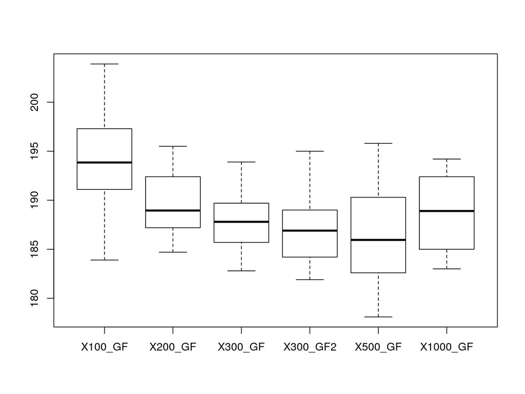

```r
setwd("../Data")
sd2 <- read.csv("aleatoric-uncertainty.csv", header = TRUE, stringsAsFactors=FALSE)
sd2 <- sd2[-c(23,24),]
boxplot(sd2)
```

- Epistemic Uncertainty

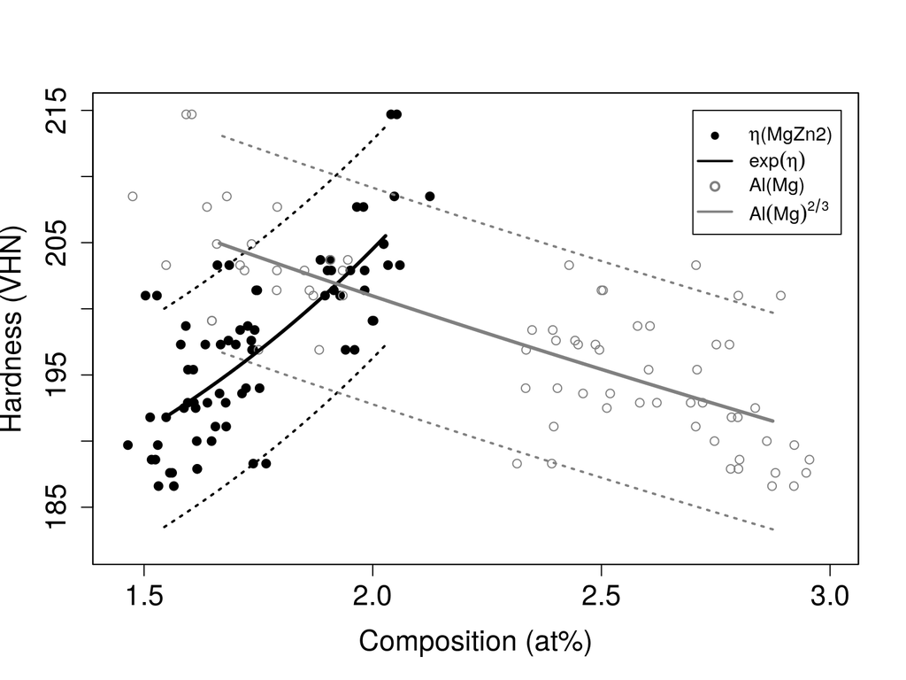

```r
fitMgZn2 <- with(df2, lm(MgZn2 ~ I(Z^2)))
summary(fitMgZn2)

fitMgexcess <- with(df2, lm(Mgexcess ~ I(Z^2)))
summary(fitMgexcess)

Z <- seq(3.175, 15.875, by=0.1)
MgZn2 <- 1.524 + 0.002*Z^2
Mgexcess <- 2.925 - 0.005*Z^2

fitMgZn2 <- with(df2, lm(Hardness ~ exp(MgZn2)))
summary(fitMgZn2)

HMgZn2 <- 169.65 + 4.72*exp(MgZn2)

fitMgexcess <- with(df2, lm(Hardness ~ I(Mgexcess^0.66)))
summary(fitMgexcess)

HMgexcess <- 235.902 - 22.109*Mgexcess^0.66

legend1 = expression(paste(eta, "(MgZn2)"))
legend2 = expression(paste(exp(eta)))
legend3 = expression(paste(Al(Mg)^{2/3}))

plot(df2$MgZn2, df2$Hardness, pch=20, col="black", xlab="Composition (at%)", ylab="Hardness (VHN)", cex=1.5,cex.axis=1.5,cex.lab=1.5, ylim=c(182,215), xlim = c(1.45,3))
legend(2.7,215, c(legend1,legend2,"Al(Mg)",legend3), pch=c(20,NA,21,NA), bty="o", lty = c(0,1,0,1), col=c("black", "black", gray(0.5), gray(0.5)), lwd = 2)
par(new=TRUE)
plot(df2$Mgexcess, df2$Hardness, pch=21, col=gray(0.5), xlab="", ylab="", xaxt="n", yaxt="n", ylim=c(182,215), xlim = c(1.45,3))
par(new=TRUE)
lines(MgZn2, HMgZn2, pch=20, col="black", xlab="", ylab="", xaxt="n", yaxt="n", ylim=c(182,215), xlim = c(1.45,3), lty =1, lwd = 3)
par(new=TRUE)
lines(MgZn2, HMgZn2 -1.96*sd(fit2$residuals), pch=20, col="black", xlab="", ylab="", xaxt="n", yaxt="n", ylim=c(182,215), xlim = c(1.45,3), lty =3, lwd = 2)
par(new=TRUE)
lines(MgZn2, HMgZn2 +1.96*sd(fit2$residuals), pch=20, col="black", xlab="", ylab="", xaxt="n", yaxt="n", ylim=c(182,215), xlim = c(1.45,3), lty =3, lwd = 2)
par(new=TRUE)
lines(Mgexcess, HMgexcess, pch=21, col=gray(0.5), xlab="", ylab="", xaxt="n", yaxt="n", ylim=c(182,215), xlim = c(1.45,3), lty = 1, lwd = 3)
par(new=TRUE)
lines(Mgexcess, HMgexcess -1.96*sd(fit1$residuals), pch=21, col=gray(0.5), xlab="", ylab="", xaxt="n", yaxt="n", ylim=c(182,215), xlim = c(1.45,3), lty = 3, lwd = 2)
par(new=TRUE)
lines(Mgexcess, HMgexcess +1.96*sd(fit1$residuals), pch=21, col=gray(0.5), xlab="", ylab="", xaxt="n", yaxt="n", ylim=c(182,215), xlim = c(1.45,3), lty = 3, lwd = 2)
```

## Challenge results

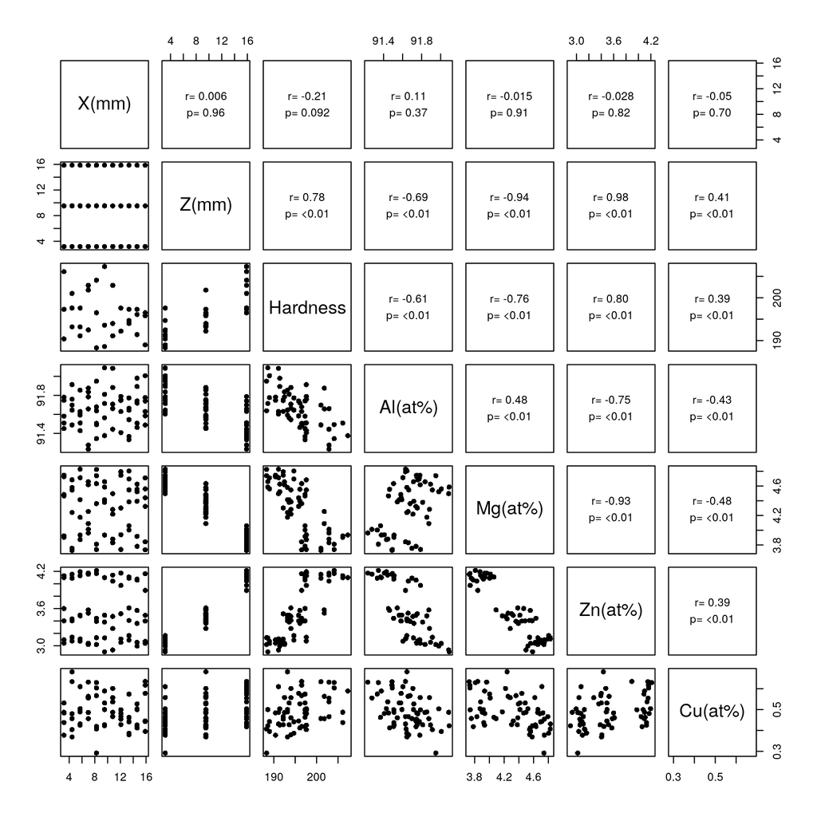

## Synthesize Results

(Predicted Value) coming from H(z) = exp(MgZn2) or (Mgexcess)^(2/3)

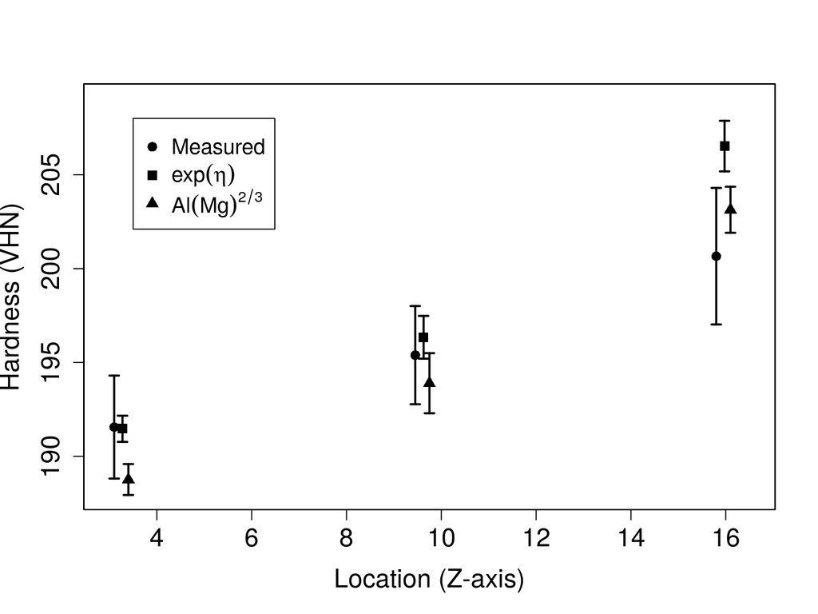

```r
df3 = data.frame(data2$Mg.at,data2$Zn.at,data2$Hardness,data2$Z.mm)
colnames(df3) <- c("Mg", "Zn", "Hardness","Z")

for(i in 1:length(df3$Mg)){
  if(df3$Mg[i] > df3$Zn[i]/2){
    df3$MgZn2[i] <- df3$Zn[i]/2
    df3$Mgexcess[i] <- df3$Mg[i] - df3$Zn[i]/2
    df3$Znexcess[i] <- 0
  }
  if(df3$Mg[i] < df3$Zn[i]/2){
    df3$MgZn2[i] <- df3$Mg[i]
    df3$Mgexcess[i] <- 0
    df3$Znexcess[i] <- df3$Zn[i] - 2*df3$Mg[i]
  }
}

columns <- c("Hppt","Hss")
df3[,columns] <- NA

# calculating predicted values using equations coming from 'lm'

for(i in 1:length(df3$MgZn2)){
  df3$Hppt[i] <- 169.6494 +  4.7194*exp(df3$MgZn2[i])
  df3$Hss[i] <- 235.902 - 22.109*((df3$Mgexcess[i])^0.66)}

avgActual <- c(1,1,1)
avgActual[1] <- with(df3, mean(Hardness[Z == "3.175"]))
avgActual[2] <- with(df3, mean(Hardness[Z == "9.525"]))
avgActual[3] <- with(df3, mean(Hardness[Z == "15.875"]))

sdActual <- c(1,1,1)
sdActual[1] <- with(df3, sd(Hardness[Z == "3.175"]))
sdActual[2] <- with(df3, sd(Hardness[Z == "9.525"]))
sdActual[3] <- with(df3, sd(Hardness[Z == "15.875"]))

avgPred <- c(1,1,1)
avgPred[1] <- with(df3, mean(Hppt[Z == "3.175"]))
avgPred[2] <- with(df3, mean(Hppt[Z == "9.525"]))
avgPred[3] <- with(df3, mean(Hppt[Z == "15.875"]))

sdPred <- c(1,1,1)
sdPred[1] <- with(df3, sd(Hppt[Z == "3.175"]))
sdPred[2] <- with(df3, sd(Hppt[Z == "9.525"]))
sdPred[3] <- with(df3, sd(Hppt[Z == "15.875"]))

avgPred2 <- c(1,1,1)
avgPred2[1] <- with(df3, mean(Hss[Z == "3.175"]))
avgPred2[2] <- with(df3, mean(Hss[Z == "9.525"]))
avgPred2[3] <- with(df3, mean(Hss[Z == "15.875"]))

sdPred2 <- c(1,1,1)
sdPred2[1] <- with(df3, sd(Hss[Z == "3.175"]))
sdPred2[2] <- with(df3, sd(Hss[Z == "9.525"]))
sdPred2[3] <- with(df3, sd(Hss[Z == "15.875"]))

x2  = c(3.1, 9.45, 15.8)
x1  = c(3.275, 9.627, 15.975)
x3  = c(3.4, 9.75, 16.1)

plot (x2, avgActual, ylim = c(188,209), xlim = c(3,16.5), pch=16, xlab = "Location (Z-axis)", ylab = "Hardness (VHN)",cex.lab=1.5, cex.axis=1.5, cex = 1.25)
legend(3.5,208, c("Measured",legend2,legend3), pch=c(16,15,17), bty="o", cex = 1.25)
segments(x2,avgActual-sdActual,x2,avgActual+sdActual, lwd = 2)
epsilon <- 0.1
segments(x2-epsilon,avgActual-sdActual,x2+epsilon,avgActual-sdActual, lwd = 2)
segments(x2-epsilon,avgActual+sdActual,x2+epsilon,avgActual+sdActual, lwd = 2)

par(new=TRUE)
plot(x1, avgPred, ylim = c(188,209), xlim = c(3,16.5), pch=15, xlab="", ylab="", xaxt="n", yaxt="n", cex = 1.25)
segments(x1,avgPred-sdPred,x1,avgPred+sdPred,lwd = 2)
epsilon <- 0.1
segments(x1-epsilon,avgPred-sdPred,x1+epsilon,avgPred-sdPred, lwd = 2)
segments(x1-epsilon,avgPred+sdPred,x1+epsilon,avgPred+sdPred, lwd = 2)

par(new=TRUE)
plot(x3, avgPred2, ylim = c(188,209), xlim = c(3,16.5), pch=17, xlab="", ylab="", xaxt="n", yaxt="n", cex = 1.25)
segments(x3,avgPred2-sdPred2,x3,avgPred2+sdPred2,lwd = 2)
epsilon <- 0.1
segments(x3-epsilon,avgPred2-sdPred2,x3+epsilon,avgPred2-sdPred2, lwd = 2)
segments(x3-epsilon,avgPred2+sdPred2,x3+epsilon,avgPred2+sdPred2, lwd = 2)
```

## Checking for Al- 5059

- Average measured hardness value for Al-5059 is in the range of 115.5 $\pm$ 1.4 VHN
- Below is the plot for predicted hardness values

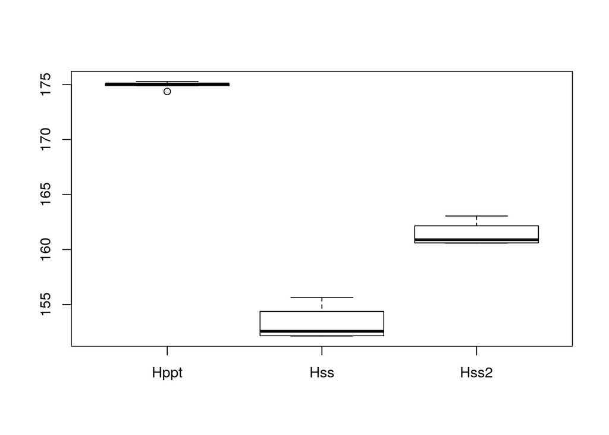

```r
setwd("../Data")
df <- read.csv("Al-5059.csv", header = TRUE, stringsAsFactors=FALSE)

N <- 6.022e23
l <- length(df$Al)
columns <- c("Alat","Mgat","Znat", "Cuat")
df[,columns] <- NA

for (i in 1:l)
  {df$Alat[i] <- df$Al[i]*N/27
  df$Znat[i] <- df$Zn[i]*N/65.4
  df$Mgat[i] <- df$Mg[i]*N/24.3
  df$Cuat[i] <- df$Cu[i]*N/63.5}


for (i in 1:l)
  {sum <- df$Alat[i] + df$Cuat[i] + df$Mgat[i] + df$Znat[i]
   df$Alat[i] <- (df$Alat[i]/sum)*100
   df$Cuat[i] <- (df$Cuat[i]/sum)*100
   df$Mgat[i] <- (df$Mgat[i]/sum)*100
   df$Znat[i] <- (df$Znat[i]/sum)*100}

df = df[,c(6,7)]
colnames(df) <- c("Mg", "Zn")

for(i in 1:length(df$Mg)){
  if(df$Mg[i] > df$Zn[i]/2){
    df$MgZn2[i] <- df$Zn[i]/2
    df$Mgexcess[i] <- df$Mg[i] - df$Zn[i]/2
    df$Znexcess[i] <- 0
  }
  if(df$Mg[i] < df$Zn[i]/2){
    df$MgZn2[i] <- df$Mg[i]
    df$Mgexcess[i] <- 0
    df$Znexcess[i] <- df$Zn[i] - 2*df$Mg[i]
  }
}

columns <- c("Hppt","Hss","Hss2")
df[,columns] <- NA

# calculating predicted values using equations coming from 'lm'

for(i in 1:length(df$MgZn2)){
  df$Hppt[i] <- 169.6494 +  4.7194*exp(df$MgZn2[i])
  df$Hss[i] <- 223.345 - 11.117*(df$Mgexcess[i])
  df$Hss2[i] <- 235.902 - 22.109*((df$Mgexcess[i])^0.66)}

boxplot(df[,c(6,7,8)])
```

```r
fit <- with(df2, lm(MgZn2 ~ Mgexcess))
summary(fit) # adj-R2: 0.944
```

```
##
## Call:
## lm(formula = MgZn2 ~ Mgexcess)
##
## Residuals:
##       Min        1Q    Median        3Q       Max
## -0.100665 -0.031677 -0.002962  0.031840  0.123747
##
## Coefficients:
##             Estimate Std. Error t value Pr(>|t|)
## (Intercept)  2.63502    0.02604   101.2   <2e-16 ***
## Mgexcess    -0.37706    0.01090   -34.6   <2e-16 ***
## ---
## Signif. codes:  0 '***' 0.001 '**' 0.01 '*' 0.05 '.' 0.1 ' ' 1
##
## Residual standard error: 0.04249 on 70 degrees of freedom
## Multiple R-squared:  0.9448, Adjusted R-squared:  0.944
## F-statistic:  1197 on 1 and 70 DF,  p-value: < 2.2e-16
```

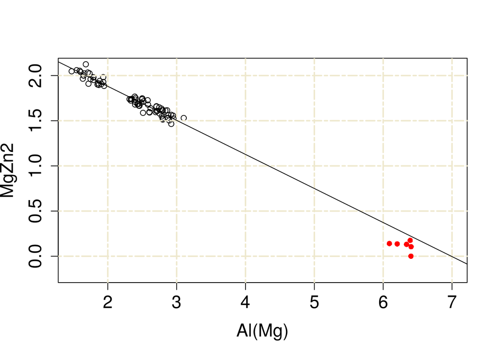

```r
plot(df2$Mgexcess,df2$MgZn2,xlab = "Al(Mg)", ylab = "MgZn2", xlim = c(1.5,7), ylim = c(-0.2, 2.1), cex.lab = 1.5, cex.axis = 1.5)
grid (NULL,NULL, lty = 6, col = "cornsilk2", lwd=2)
abline(fit)
points(df$Mgexcess, df$MgZn2, col = "red", pch =16)
```